# manzanas_reporte

```python
#Importando librerias
import pandas as pd
import numpy as np
import matplotlib.pyplot as plt
import seaborn as sns
```

### 1. Carga y exploraciòn inicial

- Carga el archivo CSV en un DataFrame.
- Usa head(), info() y describe() para conocer el contenido.

```python
df = pd.read_csv('../data/manzanas.csv')  #Iportando datos con pandas
print("HEAD")
#Mostrando las primeras 30 filas
df.head(50)
```

```
HEAD
```

|  | A_id | Size | Weight | Sweetness | Crunchiness | Juiciness | Ripeness | Acidity | Quality |
| --- | --- | --- | --- | --- | --- | --- | --- | --- | --- |
| 0 | 0 | 72.456908 | 225.980262 | 16.207798 | 6.493996 | 71.106940 | 5.098952 | 3.5016819034 | good |
| 1 | 1 | 77.729087 | 225.457190 | 15.198435 | 69.756663 | 70.511971 | 5.260259 | 3.4554381266000003 | good |
| 2 | 2 | 79.445155 | 227.837949 | 11.956943 | 6.828692 | 71.703181 | 4.988590 | 4.1243272946000005 | bad |
| 3 | 3 | 78.751328 | 226.365397 | 13.794924 | 6.951063 | 72.182782 | 3.975872 | 30.857761120346375 | good |
| 4 | 4 | 82.592012 | 227.925421 | 12.769205 | 6.723497 | 71.818525 | 4.608845 | 3.7003968072 | good |
| 5 | 5 | 73.491740 | 227.745468 | 11.851893 | 6.722113 | 67.688157 | 5.574385 | 3.0036953662 | bad |
| 6 | 6 | 82.530051 | 232.617529 | 13.525585 | 6.161101 | 71.863807 | 4.445775 | 4.0828341018 | good |
| 7 | 7 | 76.208622 | 229.313666 | 13.918386 | 6.628514 | 70.095300 | 5.292331 | 3.3059749868 | good |
| 8 | 8 | 541.672903 | 224.024778 | 13.591857 | 6.396173 | 71.375724 | 6.224276 | 2.6256190484 | bad |
| 9 | 9 | 78.616833 | 229.291487 | 10.544666 | 7.298756 | 70.236229 | 5.486257 | 4.0371215446 | bad |
| 10 | 10 | 74.871261 | 227.872789 | 12.148896 | 6.687227 | 71.422645 | 6.020949 | 3.0378383662 | bad |
| 11 | 11 | 84.656824 | 229.097316 | 12.018976 | 7.471200 | 68.747610 | 5.364297 | 3.8588647854 | good |
| 12 | 12 | 79.675458 | 227.012366 | 11.936893 | 8.206578 | 68.143267 | 4.812535 | 3.1847772006 | bad |
| 13 | 13 | 77.443492 | 227.402078 | 14.226486 | 7.877406 | 70.598540 | 5.130254 | 3.9448052168 | good |
| 14 | 14 | 636.687044 | 229.448323 | 12.388122 | 66.652603 | 69.219963 | 5.174714 | 3.9419416418 | good |
| 15 | 15 | 74.946214 | 225.526905 | 15.538242 | 7.348775 | 71.308547 | 4.973367 | 3.3832758424000002 | good |
| 16 | 16 | 77.208992 | 226.879425 | 11.671376 | 7.454879 | 71.718669 | 6.189787 | 3.4883582634 | bad |
| 17 | 17 | 79.858697 | 222.456400 | 13.149861 | 8.467660 | 70.845853 | 4.206857 | 3.8501940694 | good |
| 18 | 18 | 79.425508 | 232.759033 | 11.534598 | 8.732554 | 70.269875 | 4.977691 | 4.098756397 | bad |
| 19 | 19 | 75.994705 | 230.570348 | 12.306284 | 9.163361 | 70.936926 | 3.610948 | 27.298531031066286 | good |
| 20 | 20 | 75.564280 | 225.290066 | 10.928423 | 7.381196 | 72.445877 | 6.903934 | 3.7453551344 | bad |
| 21 | 21 | 82.237426 | NaN | 12.167730 | 10.809926 | 70.641573 | 3.879558 | 4.1285896482 | good |
| 22 | 22 | 75.394502 | 228.882399 | 13.087618 | 7.315053 | 71.794336 | 5.233842 | NaN | bad |
| 23 | 23 | 80.257857 | 228.793989 | 11.682312 | 7.519638 | 70.348323 | 5.068193 | 4.0173237082 | bad |
| 24 | 24 | 80.993625 | 227.715064 | 12.553889 | 7.893358 | 67.475474 | 4.452431 | 3.3139140286 | bad |
| 25 | 25 | 77.531010 | 224.392333 | 12.322359 | 7.277953 | 68.315470 | 5.514389 | 2.8306716354 | bad |
| 26 | 26 | 79.428673 | 229.178235 | 13.552604 | 7.689086 | 71.364848 | 5.223601 | 3.013194222 | good |
| 27 | 27 | 83.799679 | 231.071984 | 11.740230 | 8.322909 | 69.406302 | 5.111999 | 3.1204616408 | bad |
| 28 | 28 | 82.747499 | 232.650707 | 11.933488 | 7.854481 | 69.794998 | 4.603268 | 3.3683743866 | bad |
| 29 | 29 | 78.867932 | 232.455488 | 11.938409 | 7.332251 | 69.740275 | 5.240132 | 3.929190872 | bad |
| 30 | 30 | 80.779935 | 226.383536 | 10.998431 | 6.857397 | 68.359693 | 5.775796 | NaN | bad |
| 31 | 31 | 75.134344 | 229.845741 | 14.448264 | 7.659147 | 71.963013 | 4.460845 | 3.072631037 | good |
| 32 | 32 | 620.284014 | 225.229322 | 12.952117 | 6.526067 | 71.820888 | 4.787417 | 3.8333941474 | good |
| 33 | 33 | 588.120779 | 228.204821 | 14.394577 | 7.155965 | 73.089244 | 3.994403 | 4.7120217386 | bad |
| 34 | 34 | 79.934701 | 227.867512 | 14.397461 | 8.431379 | 70.495144 | 5.318802 | 4.060066105 | good |
| 35 | 35 | 78.184736 | 226.062245 | 10.547706 | 7.419554 | 70.601930 | 6.492692 | 3.403722466 | bad |
| 36 | 36 | 74.183786 | 231.339366 | 12.354017 | 7.762369 | 71.058484 | 4.983058 | 3.3009774768 | good |
| 37 | 37 | 87.501416 | 227.385307 | 10.135732 | 7.965816 | 70.474324 | 5.474929 | 3.1043888136 | good |
| 38 | 38 | 76.586235 | 224.449236 | 15.211262 | 6.917930 | 70.792179 | 5.444033 | 3.1414071134 | good |
| 39 | 39 | 82.444802 | 226.112761 | 13.573680 | 7.738771 | 72.871825 | 3.985293 | 4.103869385 | good |
| 40 | 40 | 82.273436 | 227.683033 | 12.447090 | 8.002746 | 70.242845 | 4.789766 | 3.8142259416 | bad |
| 41 | 41 | 79.327038 | 226.761532 | 13.820191 | 8.616808 | 70.595601 | 5.457683 | 4.1481849522 | good |
| 42 | 42 | 77.076647 | 225.603449 | 14.106970 | 7.245625 | 69.744511 | 5.377930 | 3.2638151816 | bad |
| 43 | 43 | 81.534923 | 231.204331 | 13.107536 | 7.725791 | 69.032884 | 4.167118 | 3.6369811214000003 | bad |
| 44 | 44 | 87.467687 | 234.407050 | 11.399230 | 7.714124 | 70.055657 | 5.328738 | 4.1254548316 | good |
| 45 | 45 | 80.063595 | 229.929342 | 12.711279 | 9.468605 | 69.634076 | 4.030549 | 3.8497583582 | good |
| 46 | 46 | 79.074003 | 228.769911 | 12.532461 | 8.012628 | 70.886756 | 5.080336 | 2.7090859654 | good |
| 47 | 47 | 77.362819 | 234.381617 | 11.590470 | 7.476719 | 71.116429 | 5.695193 | 4.219563675 | bad |
| 48 | 48 | 73.675714 | NaN | 12.145358 | 7.363693 | 70.946153 | 5.773341 | 3.7301355736 | bad |
| 49 | 49 | 77.896586 | 233.617917 | 11.418882 | 7.441132 | 69.985603 | 5.665430 | 4.1730096742 | bad |

```python
print("INFO")
df.info() # Verificando la informacion general
print("DISCRIBE")
df.describe() #Estadisrticas basicas
```

```
INFO
<class 'pandas.core.frame.DataFrame'>
RangeIndex: 4000 entries, 0 to 3999
Data columns (total 9 columns):
 #   Column       Non-Null Count  Dtype
---  ------       --------------  -----
 0   A_id         4000 non-null   int64
 1   Size         3880 non-null   float64
 2   Weight       3880 non-null   float64
 3   Sweetness    4000 non-null   float64
 4   Crunchiness  3880 non-null   float64
 5   Juiciness    4000 non-null   float64
 6   Ripeness     4000 non-null   float64
 7   Acidity      3881 non-null   object
 8   Quality      4000 non-null   object
dtypes: float64(6), int64(1), object(2)
memory usage: 281.4+ KB
DISCRIBE
```

|  | A_id | Size | Weight | Sweetness | Crunchiness | Juiciness | Ripeness |
| --- | --- | --- | --- | --- | --- | --- | --- |
| count | 4000.000000 | 3880.000000 | 3880.000000 | 4000.000000 | 3880.000000 | 4000.000000 | 4000.000000 |
| mean | 1999.500000 | 94.515423 | 286.188355 | 12.717713 | 9.280662 | 70.307271 | 5.149483 |
| std | 1154.844867 | 87.595191 | 327.681811 | 1.166064 | 10.257560 | 1.158171 | 0.562328 |
| min | 0.000000 | 66.411764 | 218.560244 | 8.863309 | 3.972471 | 66.422862 | 3.240620 |
| 25% | 999.750000 | 76.616864 | 226.867309 | 11.956945 | 7.052908 | 69.519229 | 4.768497 |
| 50% | 1999.500000 | 79.152324 | 228.518195 | 12.697145 | 7.528237 | 70.320531 | 5.151033 |
| 75% | 2999.250000 | 81.867842 | 230.267036 | 13.481153 | 7.995647 | 71.101586 | 5.529863 |
| max | 3999.000000 | 640.367782 | 2233.299942 | 16.824949 | 83.198105 | 74.418642 | 7.171351 |

### Analisis

- Contamos 9 columnas: Ai_id, Size, Weight, Sweetness, Crunchiess, Juiciness, Ripeness, Acidity, Quality.
- Encontramos que las variables Crunchines (120), Weight (120), Size (120), Acidity (119) cuentan con valorees nulos
- Todas la variables son de tipo númerico a excepción de Acidity y Quality que son categoricas. Mientras qie el A_id es entero.
- La variable Acidity no corresponde con su tipo a los datos que contiene

### 2. Limpieza de datos

- Verifica la existencia de valores nulos o duplicados.
- Asegurate de que los tipos de datos sean correctos.
- Trata los outliers si se identifican.

```python
#Convirtiendo Acidity a numerico
df['Acidity'] = pd.to_numeric(df['Acidity'], errors='coerce')
```

```python
#Encontrando valores nulos
df.isnull().sum()
```

```
A_id             0
Size           120
Weight         120
Sweetness        0
Crunchiness    120
Juiciness        0
Ripeness         0
Acidity        120
Quality          0
dtype: int64
```

```python
#Verificando diferencias en variables categóricas

# 1. Ver valores únicos actuales (para diagnosticar)
print("Valores únicos en 'Calidad' ANTES de la corrección:")
print(df['Quality'].unique())

# 2. Estandarizar a minúsculas (o mayúsculas) y eliminar espacios
df['Quality'] = df['Quality'].str.strip().str.lower()  # " GOOD " -> "good"

# 3. Opcional: Mapear a nombres consistentes (ej: "buena"/"mala")
# df['Calidad'] = df['Calidad'].map({'good': 'buena', 'bad': 'mala'})

# 4. Verificar después de la corrección
print("\nValores únicos en 'Calidad' DESPUÉS de la corrección:")
print(df['Quality'].unique())

# 5. Contar frecuencias
print("\nConteo de valores:")
print(df['Quality'].value_counts())
```

```
Valores únicos en 'Calidad' ANTES de la corrección:
['good' 'bad' 'GOOD' 'BAD']

Valores únicos en 'Calidad' DESPUÉS de la corrección:
['good' 'bad']

Conteo de valores:
Quality
good    2004
bad     1996
Name: count, dtype: int64
```

```python
#Encontrando valores duplicados
df.duplicated().sum()  # Verificando si hay filas duplicadas
```

```
0
```

```python
#Eliminar filas con valores nulos
df_cleaned = df.dropna()
```

```python
#Eliminando columna A_id
df_cleaned = df_cleaned.drop(columns=['A_id'])
```

```python
#Encontrando valores nulos
print(df_cleaned.isnull().sum())
print(df_cleaned.info())
```

```
Size           0
Weight         0
Sweetness      0
Crunchiness    0
Juiciness      0
Ripeness       0
Acidity        0
Quality        0
dtype: int64
<class 'pandas.core.frame.DataFrame'>
Index: 3543 entries, 0 to 3999
Data columns (total 8 columns):
 #   Column       Non-Null Count  Dtype
---  ------       --------------  -----
 0   Size         3543 non-null   float64
 1   Weight       3543 non-null   float64
 2   Sweetness    3543 non-null   float64
 3   Crunchiness  3543 non-null   float64
 4   Juiciness    3543 non-null   float64
 5   Ripeness     3543 non-null   float64
 6   Acidity      3543 non-null   float64
 7   Quality      3543 non-null   object
dtypes: float64(7), object(1)
memory usage: 249.1+ KB
None
```

```python
# 1. Copiar el DataFrame original
df_cleane = df_cleaned.copy()

# 2. Seleccionar columnas numéricas
numeric_cols = df_cleaned.select_dtypes(include=['float64', 'int64']).columns

# 3. Función para reemplazar outliers por la mediana
def replace_outliers_with_median(df, columns):
    for col in columns:
        Q1 = df[col].quantile(0.25)
        Q3 = df[col].quantile(0.75)
        IQR = Q3 - Q1
        lower_bound = Q1 - 1.5 * IQR
        upper_bound = Q3 + 1.5 * IQR

        # Calcular la mediana de la columna (sin outliers)
        median = df[(df[col] >= lower_bound) & (df[col] <= upper_bound)][col].median()

        # Reemplazar outliers
        df[col] = np.where((df[col] < lower_bound) | (df[col] > upper_bound), median, df[col])
    return df

# 4. Aplicar la función
df_replaced = replace_outliers_with_median(df_cleaned, numeric_cols)

# 5. Verificar resultados
print("Resumen de cambios:")
print(f"- Outliers reemplazados en: {list(numeric_cols)}")
print(f"- Ejemplo en 'Peso': Mediana = {df_cleaned['Weight'].median():.2f}")
```

```
Resumen de cambios:
- Outliers reemplazados en: ['Size', 'Weight', 'Sweetness', 'Crunchiness', 'Juiciness', 'Ripeness', 'Acidity']
- Ejemplo en 'Peso': Mediana = 228.43
```

```python
print(df_cleaned.info())
print(df_cleaned.head())
print(df_cleaned.describe)
```

```
<class 'pandas.core.frame.DataFrame'>
Index: 3543 entries, 0 to 3999
Data columns (total 8 columns):
 #   Column       Non-Null Count  Dtype
---  ------       --------------  -----
 0   Size         3543 non-null   float64
 1   Weight       3543 non-null   float64
 2   Sweetness    3543 non-null   float64
 3   Crunchiness  3543 non-null   float64
 4   Juiciness    3543 non-null   float64
 5   Ripeness     3543 non-null   float64
 6   Acidity      3543 non-null   float64
 7   Quality      3543 non-null   object
dtypes: float64(7), object(1)
memory usage: 249.1+ KB
None
        Size      Weight  Sweetness  Crunchiness  Juiciness  Ripeness  \
0  72.456908  225.980262  12.688757     6.493996  71.106940  5.098952
1  77.729087  225.457190  15.198435     7.497543  70.511971  5.260259
2  79.445155  227.837949  11.956943     6.828692  71.703181  4.988590
3  78.751328  226.365397  13.794924     6.951063  72.182782  3.975872
4  82.592012  227.925421  12.769205     6.723497  71.818525  4.608845

    Acidity Quality
0  3.501682    good
1  3.455438    good
2  4.124327     bad
3  3.604264    good
4  3.700397    good
<bound method NDFrame.describe of            Size      Weight  Sweetness  Crunchiness  Juiciness  Ripeness  \
0     72.456908  225.980262  12.688757     6.493996  71.106940  5.098952
1     77.729087  225.457190  15.198435     7.497543  70.511971  5.260259
2     79.445155  227.837949  11.956943     6.828692  71.703181  4.988590
3     78.751328  226.365397  13.794924     6.951063  72.182782  3.975872
4     82.592012  227.925421  12.769205     6.723497  71.818525  4.608845
...         ...         ...        ...          ...        ...       ...
3994  82.816765  225.870110  12.815867     7.763938  70.633817  5.768249
3995  80.112834  228.292147  10.771271     7.236526  71.018792  5.673216
3997  74.994421  226.578805  11.535723     7.328611  71.319825  6.429158
3998  72.384793  227.153061  14.419838     6.899835  71.296861  5.064347
3999  80.529225  227.255192  13.072730     6.422963  70.760006  4.767029

       Acidity Quality
0     3.501682    good
1     3.455438    good
2     4.124327     bad
3     3.604264    good
4     3.700397    good
...        ...     ...
3994  3.354149    good
3995  3.627557     bad
3997  3.333078     bad
3998  3.154056    good
3999  3.919959    good

[3543 rows x 8 columns]>
```

- Se elimino la columna A_id ya que no tenia utilidad en nuestro analisis
- Se eliminaron las filas que contenian NaN ya que correspondian a menos del 12% del total del df
- Se estandarizaron los outliners usando la mediana de cada variable

### 3. Analisis exploratorio de datos (EDA)

- Analiza las distribuciones de cada variable (histogramas, etc).
- Usa graficas de dispersin y boxplots para comparar variables con la calidad.
- Muestra la matriz de correlacion y un mapa de calor

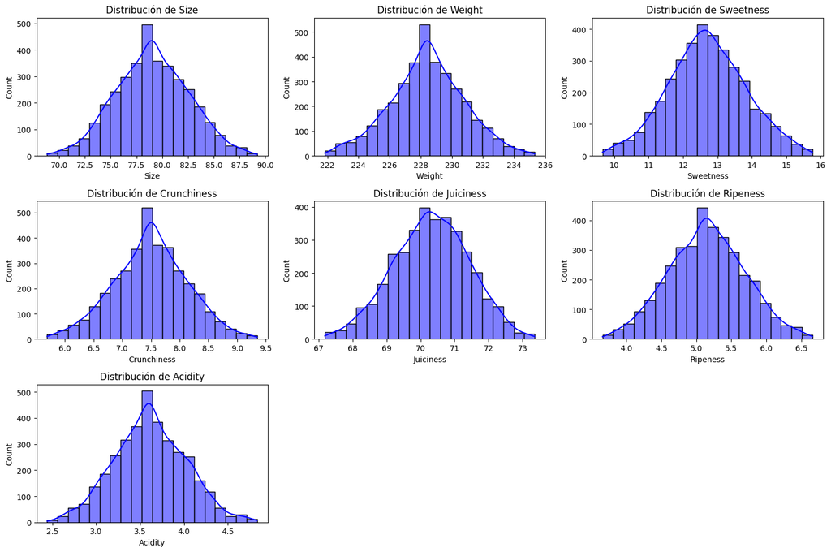

```python
#Generando histograma para todo el df_cleaned
plt.figure(figsize=(15, 10))
for i, col in enumerate(numeric_cols, 1):
    plt.subplot(3, 3, i)
    sns.histplot(df_cleaned[col], kde=True, bins=20, color='blue')
    plt.title(f'Distribución de {col}')
plt.tight_layout()
plt.show()
```

[figure not shown]

```python
# Graficas de dispersiom para comparar las variables
plt.figure(figsize=(15, 10))
for i, col in enumerate(numeric_cols, 1):
    if col != 'Quality':  # Evitar comparar con la columna 'Weight'
        plt.subplot(3, 3, i)
        sns.scatterplot(data=df_cleaned, x='Weight', y=col)
        plt.title(f'Calidad vs {col}')
```

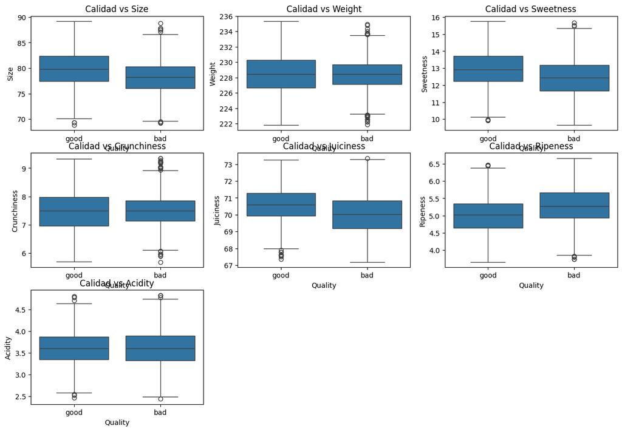

```python
# boxplor para comparar las variables con quality
plt.figure(figsize=(15, 10))
for i, col in enumerate(numeric_cols, 1):
    if col != 'Quality':  # Evitar comparar con la columna 'Weight'
        plt.subplot(3, 3, i)
        sns.boxplot(data=df_cleaned, x='Quality', y=col)
        plt.title(f'Calidad vs {col}')
```

```python
#Transformando la columna Quality a numérica
df_cleaned['Quality'] = df_cleaned['Quality'].map({'good': 1, 'bad': 0})
# Verificando la transformación
print("\nValores únicos en 'Quality' DESPUÉS de la transformación:")
print(df_cleaned['Quality'].unique())
```

```
Valores únicos en 'Quality' DESPUÉS de la transformación:
[1 0]
```

```python
#Revisando tipos de datos
df_cleaned.dtypes
```

```
Size           float64
Weight         float64
Sweetness      float64
Crunchiness    float64
Juiciness      float64
Ripeness       float64
Acidity        float64
Quality          int64
dtype: object
```

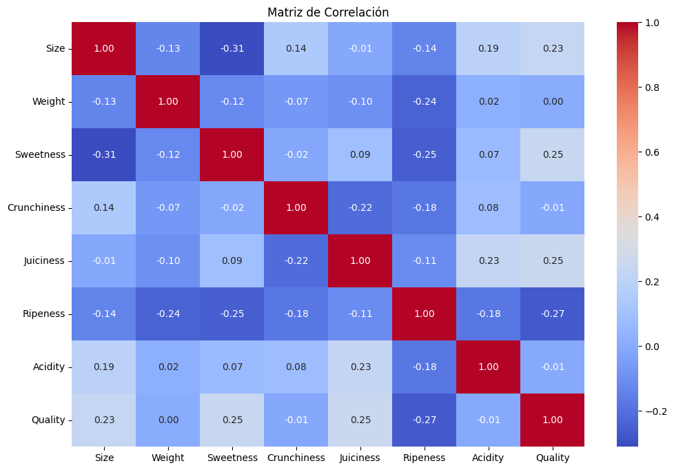

```python
#Generando matriz de correlación
plt.figure(figsize=(12, 8))
sns.heatmap(df_cleaned.corr(), annot=True, cmap='coolwarm', fmt='.2f')
plt.title('Matriz de Correlación')
```